# K-Nearest Neighbors

## Where we left off

- **Day 12:** logistic regression.
  - Assumes a shape (the S-curve), then estimates \(\beta_0, \beta_1, \dots\) by optimizing.
  - Interpretable: each coefficient’s sign says which way it pushes.
- **Today: K-nearest neighbors (KNN).**
  - No equation and no coefficients: predict from the most similar past cases.
  - One dial, \(K\), sets how flexible it is.
  - Back to Day 9: training vs test error, bias and variance.

## Ask the neighbors

> **We’re ordering a T-shirt for a new student: 176 cm, 75 kg. Medium or Large?**

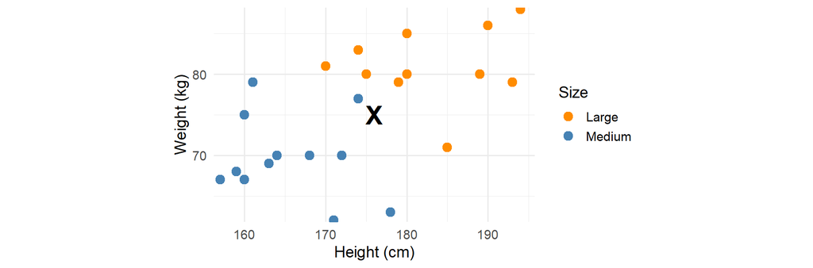

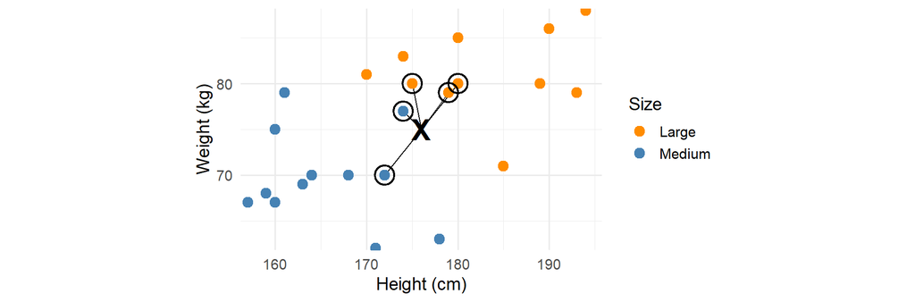

- Each dot: a past student and the size that fit them.
- 5 nearest: 3 Large, 2 Medium → P(Large) = 3/5 → predict **Large**.

## What we just did: the KNN classifier

The same three steps work for any new case and any number of predictors.

1. **Measure** the distance from the new case to every training case. For the new student: \(d = \sqrt{(\text{height} - 176)^2 + (\text{weight} - 75)^2}\). More predictors, more terms.
2. **Take** the \(K\) closest. (We used \(K = 5\).)
3. **Vote:** P(Large) = the share of those \(K\) that are Large (3/5). Predict the majority.

In R, from the `class` package:

```r
knn(train = train_X, test = test_X, cl = train_y, k = 5)
```

## Parametric vs non-parametric

|  | Logistic regression | KNN |
| --- | --- | --- |
| **Assumes a shape?** | Yes: the S-curve, linear in *z* | No |
| **Optimizes?** | Yes: the β’s, by maximum likelihood | No. Nothing to fit |
| **We choose** | The cutoff | *K* and the cutoff |
| **Keeps, to predict** | Just β₀, β₁, … | The whole training set |
| **Flexibility** | Set by the terms we include | Set by *K* |
| **Explain a prediction?** | Yes, with the coefficients | Only “similar cases were Yes” |

- **Parametric:** estimate a fixed set of parameters. **Non-parametric:** let the data set the shape.
- Day 9’s table: KNN sits at the flexible, hard-to-interpret end.

## 1. Choosing K

## K is a flexibility dial

> **Which \(K\) would you trust on new data?**

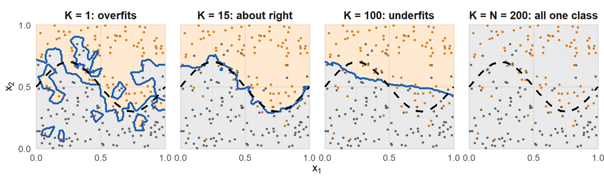

- **Dots:** **orange = Yes**, **dark = No**. **Blue line** **and shading:** what KNN predicts.
- **Dashed:** the truth (Yes and No 50/50). Above it, Yes is *more likely*, not certain.

## Training vs test error

> **For KNN, choosing \(K\) by training error is especially bad. Why?**

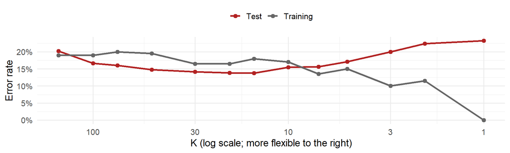

- Test error is lowest at \(K =\) 15: Day 9’s U-shape again.

## Back to the loans

> **Does KNN beat “always No” on customers it hasn’t seen?**

Train on 5,000 customers (balance and income); test on the other 5,000.

| Classifier | Training error | Test error | Test recall |
| --- | --- | --- | --- |
| Always No (baseline) | 3.4% | 3.3% | 0% |
| KNN, K = 1 | 0.0% | 4.5% | 33% |
| KNN, K = 25 | 2.7% | 2.9% | 26% |
| KNN, K = 300 | 3.4% | 3.3% | 0% |

- \(K = 1\) is perfect on its training data and **worse than the baseline** on new customers.
- Too large a \(K\) and every vote goes to the majority: \(K = 300\) is the baseline.

## Bias and variance, again

> **Draw 3 training sets (one color each). How much does KNN’s boundary move?**

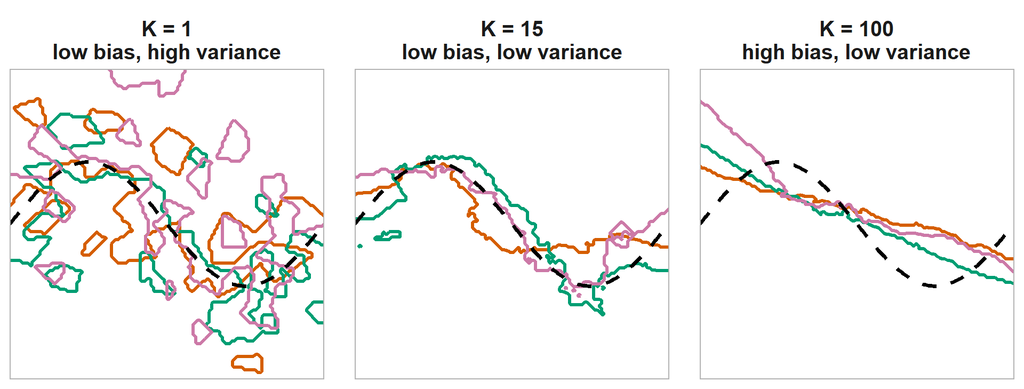

Dashed: the true boundary.

## 2. Distance needs a common scale

## Same students, different units

> **Record height in meters, not cm. Should the new student’s T-shirt change?**

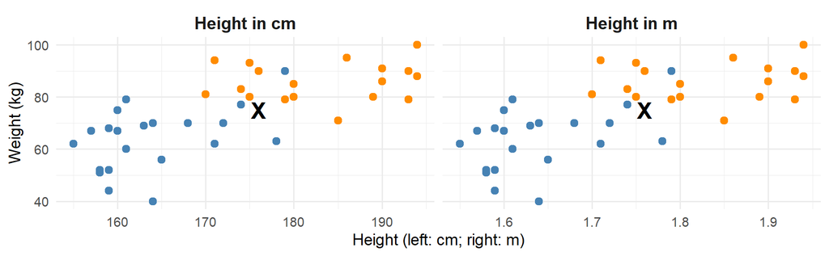

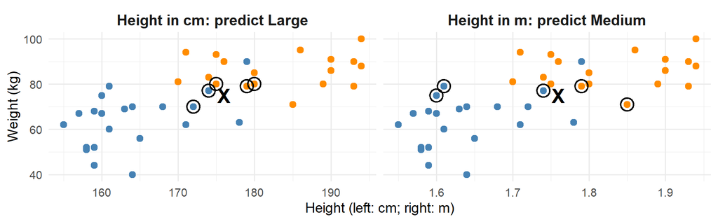

- In meters, heights differ by only ~0.1, so **weight alone** picks the neighbors.
- **Standardize** first (subtract the mean, divide by the SD; `scale()`). Then cm or m gives the same answer.

## KNN or logistic regression?

> **Which method makes fewer mistakes on new data?** Each cell: test error rate (lower is better).

| Data | True boundary | Logistic regression | Best KNN |
| --- | --- | --- | --- |
| Simulated | Curved | 15.4% | 13.8% (K = 15) |
| Loans (`Default`) | Nearly straight | 2.7% | 2.9% (K = 25) |

- Curved boundary: KNN’s flexibility pays off.
- Nearly straight boundary: logistic regression is at least as good, **and** it explains itself.
- No method wins everywhere. Test error decides; interpretability breaks ties.

## Two ways to carve up the space

> **Why does KNN win on the curved data? Where does each method predict Yes?**

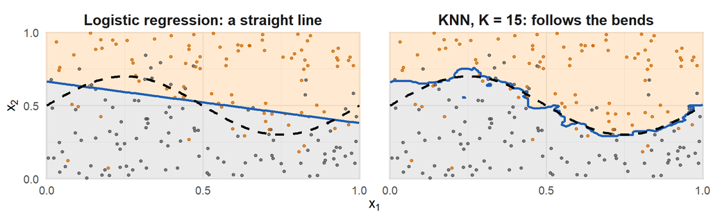

- **Blue line**: each method’s boundary. **Dashed:** the truth.
- With \(x_1\) and \(x_2\), logistic draws a straight line. KNN finds the shape itself.

## The same comparison on the loans

> **Why don’t the loans reward KNN’s flexibility?**

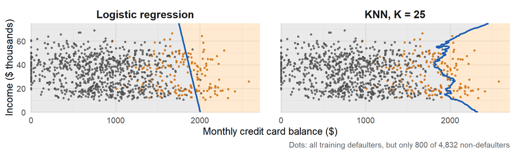

- Both put the boundary near $2,000: Day 11’s rule, found from the data.
- KNN’s wiggles add variance, not accuracy. When the two are close, prefer logistic: it’s **more stable**, and it explains itself.

## Summary

**KNN** classifies a new case by a vote of its \(K\) nearest training cases.

- **Non-parametric:** no assumed shape, no coefficients. Flexibility comes from \(K\).
- **Small \(K\):** flexible, low bias, high variance. \(K = 1\) has 0% training error and can lose to the baseline on new data.
- **Large \(K\):** rigid, high bias, low variance. Very large \(K\) just predicts the majority class.
- Choose \(K\) by **test** error, never training error.
- **Standardize** the predictors, or the one with the biggest spread decides who counts as a neighbor.

**Next time:** cross-validation, a better way to estimate test error than one split.

## For rest of class

- Work on the `day13_activity`
  - back to Day 12’s colleges: can KNN beat your logistic regression on colleges it hasn’t seen? And what happens when tuition is in dollars?
- Ask me questions if you run into issues